# New Sampling points

09/06, 2021

## Points already planned to be sampled

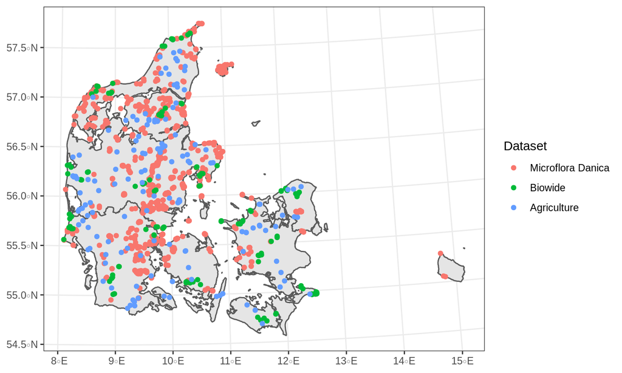

## Objective

- Find the points furthest away environmentally from the current points
- Find the most stable, more increase and more decrease of species Richness
- Candidate points extracted from Novana dataset
- 48,190 Candidate points

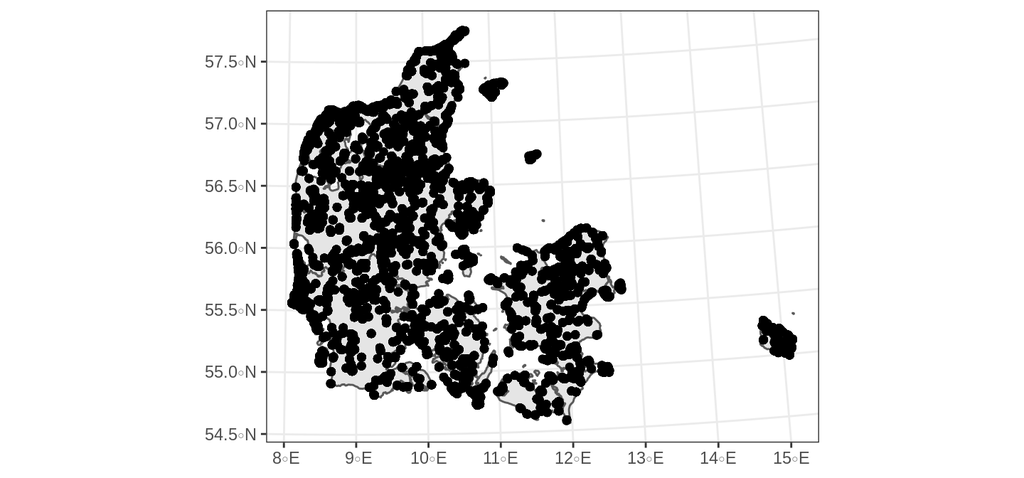

## Environmental distance

## Methods

- From the remaining Novana data points we searched the furthest points in environmental space
- Variables:
  - Mean anual temperature
  - Temperature seasonality
  - Annual precipitation
  - Precipitation seasonality
  - Topographic wetness index
  - Vegetation density
  - pH Surface
  - pH deep
  - Bin of canopy height (<1,1-3, 3-10, >10)

## Map of selected points

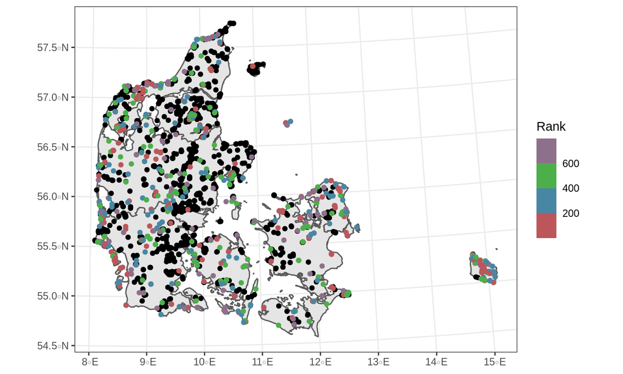

## NMDS of selected points

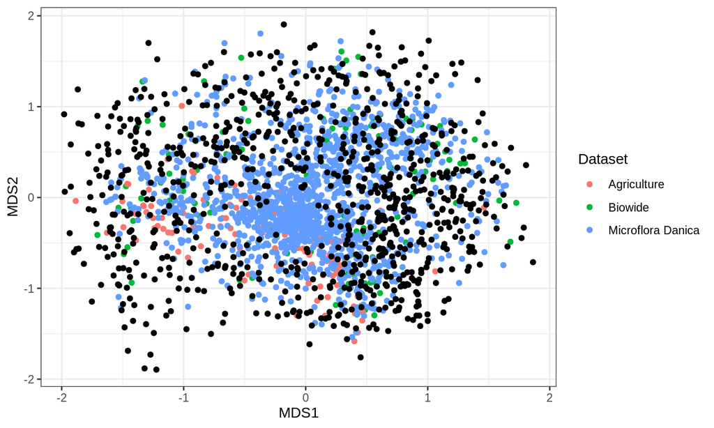

[figure not shown]

## Environmental space

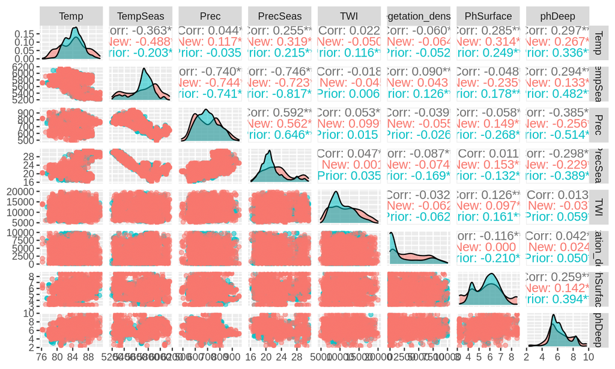

## Selection by species richness change

## Method

- From Novana dataset select the point with at least 4 years of sampling
- Make a linear regression between Richness (Only positive species), and year
- If slope is non significative the sampling point is considered to be stable
  - Select the 34 lowest absolute value slope
- If slope is significative and positive the sampling point is considered to be of increasing richness
  - Select the 34 highest slope value
- If slope is significative and negative the sampling point is considered to be of decreasing richness
  - Select the 34 lowest slope value

## Selected points

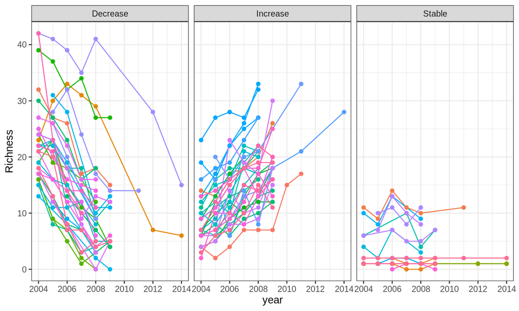

## Selected points (map)

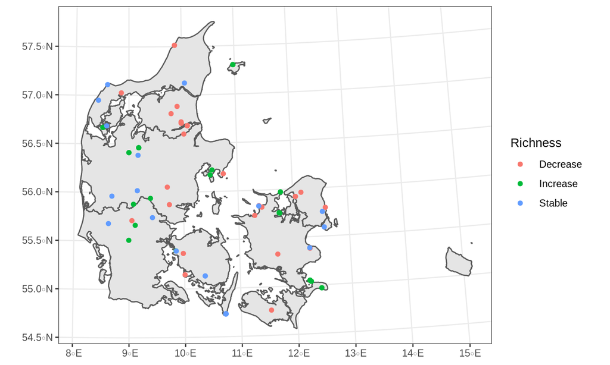

## Possible enhancements

- Add biodiversity layer for distances
- Include new protected areas as a focused area
- Include other variables of interest